# Extra Programming Examples

## Preface

### R packages

In this practical, a number of R packages are used. The packages used (with versions that were used to generate the solutions) are:

- R version 4.0.3 (2020-10-10)
- `survival` (version: 3.2.7)

### Datasets

For this practical, we will use the **heart** and **retinopathy** data sets from the `survival` package. More details about the data sets can be found in:

https://stat.ethz.ch/R-manual/R-devel/library/survival/html/heart.html

https://stat.ethz.ch/R-manual/R-devel/library/survival/html/retinopathy.html

## Combinations of Functions and Loops

### Common R Objects

#### Task 1

Examine the following code in R.

```r
h <- function(k){
       if (k <= 20){
        3 * k
      } else {
      2 * k
    }
}
```

Investigate what this code takes as an input (e.g. scalar, vector, matrix, data.frame, list) and what the output will be in every case.

#### Solution 1

```r
h <- function(k){
       if (k <= 20){
        3 * k
      } else {
      2 * k
    }
}
scalar_test <- 10
vec_test <- c(1:10)
mat_test <- matrix(1:6, 3, 3)
df_test <- data.frame(v1 = 1:10, v2 = sample(0:1, 10, replace = TRUE))
list_test <- list(l1 = 1:30, l2 = c("m", "f"), l3 = c(TRUE, TRUE, FALSE, FALSE, FALSE))
# h(scalar_test)
# h(vec_test)
# h(mat_test)
# h(df_test)
# h(list_test)
```

#### Task 2

Examine the following code in R.

```r
h <- function(k){
  for(i in 1:length(k)){
    k[i]<- if (k[i] <= 20){
      3 * k[i]
    } else {
      2 * k[i]
    }
  }
  k
}
```

Investigate what this code takes as an input (e.g. scalar, vector, matrix, data.frame, list) and what the output will be in every case.

#### Solution 2

```r
h <- function(k){
  for(i in 1:length(k)){
    k[i]<- if (k[i] <= 20){
      3 * k[i]
    } else {
      2 * k[i]
    }
  }
  k
}
scalar_test <- 10
vec_test <- c(1:10)
mat_test <- matrix(1:6, 3, 3)
df_test <- data.frame(v1 = 1:10, v2 = sample(0:1, 10, replace = TRUE))
list_test <- list(l1 = 1:30, l2 = c("m", "f"), l3 = c(TRUE, TRUE, FALSE, FALSE, FALSE))
# h(scalar_test)
# h(vec_test)
# h(mat_test)
# h(df_test)
# h(list_test)
```

#### Task 3

Define a function (with the name `mysummary`) that takes one parameter (let’s call it `x`) and investigates if it is a data frame, a factor, or a numeric variable and returns the message “This is a data.frame” if `x` is a data frame, “This is a factor” is `x` is a factor and “This is numeric” if `x` is numeric.

Use an if statement. When you want to display results from the function you can use the print(…) function.

#### Solution 3

```r
mysummary <- function(x){
  if(is.data.frame(x)){
    print('This is a data.frame')
  }else if(is.factor(x)){
    print('This is a factor')
  }else if(is.numeric(x)){
    print('This is numeric')
  }
}
df_test <- data.frame(v1 = 1:10, v2 = sample(0:1, 10, replace = TRUE))
vec1_test <- as.factor(c("y", "n", "n", "n"))
vec2_test <- 1:10
mysummary(df_test)
```

```
## [1] "This is a data.frame"
```

```r
mysummary(vec1_test)
```

```
## [1] "This is a factor"
```

```r
mysummary(vec2_test)
```

```
## [1] "This is numeric"
```

### Data Exploration

#### Task 1

Extend the previous function `mysummary` to take again one parameter (let’s call it `x`) but to return also some descriptive statistics. We therefore modify the function in such a way that a frequency table is given for factors and the mean and standard deviation are given for numeric data. For a data frame, return only an extra message that indicates that this is not implemented yet.

Use the functions table(…), mean(…) and sd(…).

#### Solution 1

```r
mysummary <- function(x){
  if(is.data.frame(x)){
    print('This is a data.frame')
    print('Not yet implemented')
  }else if(is.factor(x)){
    print('This is a factor')
    print(table(x))
  }else if(is.numeric(x)){
    print('This is numeric')
    print('mean')
    print(mean(x))
    print('sd')
    print(sd(x))
  }
}
df_test <- data.frame(v1 = 1:10, v2 = sample(0:1, 10, replace = TRUE))
vec1_test <- as.factor(c("y", "n", "n", "n"))
vec2_test <- 1:10
mysummary(df_test)
```

```
## [1] "This is a data.frame"
## [1] "Not yet implemented"
```

```r
mysummary(vec1_test)
```

```
## [1] "This is a factor"
## x
## n y
## 3 1
```

```r
mysummary(vec2_test)
```

```
## [1] "This is numeric"
## [1] "mean"
## [1] 5.5
## [1] "sd"
## [1] 3.02765
```

#### Task 2

The previous function `mysummary` still does not do anything useful when we apply it on the whole data.frame. Extend the function to take again one parameter (let’s call it `x`) but to return also some descriptive statistics for the data frame.

This can be solved in the following way: whenever the function is called using a data.frame as argument, we use a for loop to loop over its columns. Within this loop we let the function call itself but now using the column as argument.

#### Solution 2

```r
mysummary <- function(x){
  if(is.data.frame(x)){
    print('This is a data.frame')
    for(i in 1:ncol(x)){
      print(names(x)[i])
      mysummary(x[,i])
    }
  }else if(is.factor(x)){
    print('This is a factor')
    print(table(x))
  }else if(is.numeric(x)){
    print('This is numeric')
    print('mean')
    print(mean(x))
    print('sd')
    print(sd(x))
  }
}
df1_test <- data.frame(v1 = 1:10, v2 = sample(0:1, 10, replace = TRUE))
df2_test <- data.frame(v1 = 1:10, v2 = sample(c("no", "yes"), 10, replace = TRUE))
mysummary(df1_test)
```

```
## [1] "This is a data.frame"
## [1] "v1"
## [1] "This is numeric"
## [1] "mean"
## [1] 5.5
## [1] "sd"
## [1] 3.02765
## [1] "v2"
## [1] "This is numeric"
## [1] "mean"
## [1] 0.6
## [1] "sd"
## [1] 0.5163978
```

```r
mysummary(df2_test)
```

```
## [1] "This is a data.frame"
## [1] "v1"
## [1] "This is numeric"
## [1] "mean"
## [1] 5.5
## [1] "sd"
## [1] 3.02765
## [1] "v2"
```

### Data Manipulation

#### Task

Create a function with the name `std_num` that takes as input a data frame (let’s call it `DF`), standardizes all the numerical variables and returns the new data frame. Apply this function to the **heart** data set.

Use an if statement and a for loop. Note that you will have to transform some variables to factors first.

#### Solution

```r
heart$event <- as.factor(heart$event)
heart$surgery <- as.factor(heart$surgery)
heart$transplant <- as.factor(heart$transplant)
heart$id <- as.factor(heart$id)

std_num <- function(DF){
     for (j in 1:dim(DF)[2]){
            if (is.numeric(DF[,j])){
             DF[,j] <- (DF[,j] - mean(DF[,j]))/sd(DF[,j])
          }
            }
      DF
}
std_num(heart)
```

|  | start | stop | event | age | year | surgery | transplant | id |
| --- | --- | --- | --- | --- | --- | --- | --- | --- |
| 1 | -0.42162096 | -0.42252929 | 1 | -1.55746789 | -1.82477739 | 0 | 0 | 1 |
| 2 | -0.42162096 | -0.54541148 | 1 | 0.67088704 | -1.75276529 | 0 | 0 | 2 |
| 3 | -0.42162096 | -0.55937536 | 0 | 0.93217452 | -1.74676428 | 0 | 0 | 3 |
| 4 | -0.39444509 | -0.51748371 | 1 | 0.93217452 | -1.74676428 | 0 | 1 | 3 |
| 5 | -0.42162096 | -0.46162817 | 0 | -0.55765819 | -1.62374362 | 0 | 0 | 4 |
| 6 | 0.55671031 | -0.45324984 | 1 | -0.55765819 | -1.62374362 | 0 | 1 | 4 |
| 7 | -0.42162096 | -0.51189816 | 1 | -2.62528789 | -1.55923279 | 0 | 0 | 5 |
| 8 | -0.42162096 | -0.55378981 | 1 | 0.96385453 | -1.50822422 | 0 | 0 | 6 |
| 9 | -0.42162096 | -0.41973652 | 0 | 0.56829029 | -1.46471692 | 0 | 0 | 7 |
| 10 | 0.96434834 | 1.32295631 | 1 | 0.56829029 | -1.46471692 | 0 | 1 | 7 |

[output cut: 162 more lines]

### Data Visualization

#### Task 1

Create a for loop that goes through the columns of the **retinopathy** data set and plots each column. If the column is a numerical variable then use a density plot, if the column is a categorical variable then use a barchart. Create a plot with multiple panels.

Use an if statement. Use the function par(mfrow = …) to create multiple plots. Note that you will have to transform some variables to factors first.

#### Solution 1

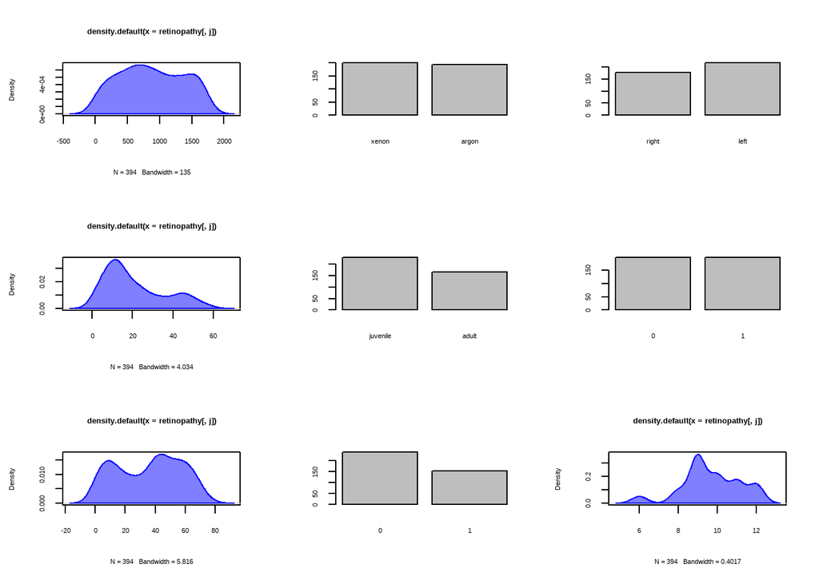

```r
retinopathy$trt <- as.factor(retinopathy$trt)
retinopathy$status <- as.factor(retinopathy$status)

par(mfrow = c(3, 3))
for (j in 1:dim(retinopathy)[2]){
  if (is.numeric(retinopathy[,j])){
    plot(density(retinopathy[,j]), col = rgb(0,0,1,0.5))
    polygon(density(retinopathy[,j]), col = rgb(0,0,1,0.5), border = "blue")
  } else if (is.factor(retinopathy[,j])){
    plot(retinopathy[,j])
  }
}
```

#### Task 2

Create a function that applies the previous code in any data set. The name of the function will be `plot_summary` and it will take as input a data frame (let’s call it `dt`) and the dimension of the panel that includes the plots. In particular, `dim_row` represents the rows and `dim_col` the columns. The function will return a plot for each column. If the column is a numerical variable then use a density plot, if the column is categorical variable then use a barchart. Apply this function to the **retinopathy** data set.

Use an if statement and a for loop. Use the function par(mfrow = …) to create multiple plots. Note that you will have to transform some variables to factors first.

#### Solution 2

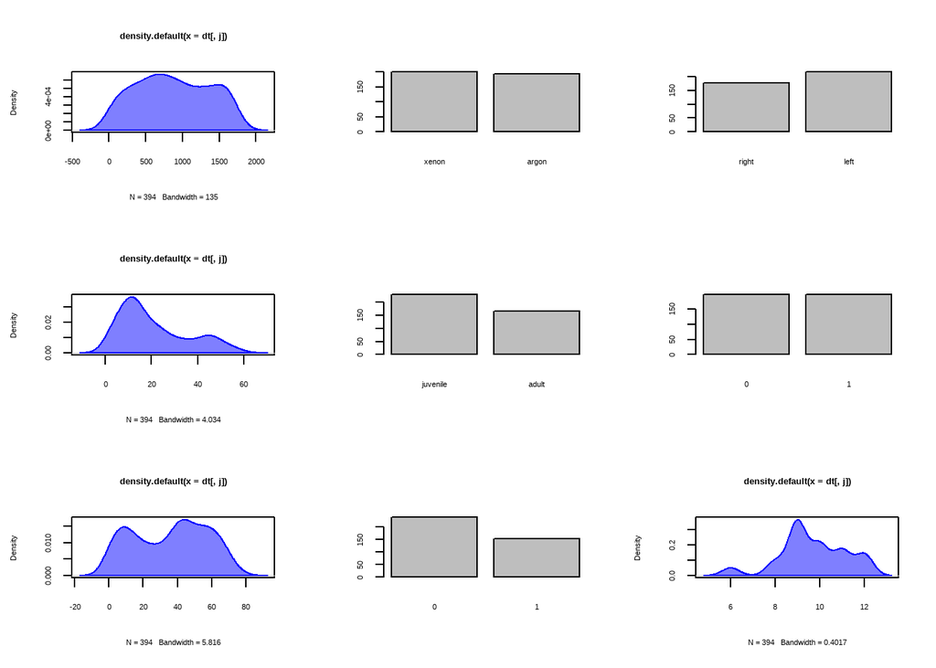

```r
retinopathy$trt <- as.factor(retinopathy$trt)
retinopathy$status <- as.factor(retinopathy$status)

plot_summary <- function(dt, dim_row, dim_col){
  par(mfrow = c(dim_row, dim_col))
  for (j in 1:dim(dt)[2]){
    if (is.numeric(dt[,j])){
      plot(density(dt[,j]), col = rgb(0,0,1,0.5))
      polygon(density(dt[,j]), col = rgb(0,0,1,0.5), border = "blue")
    } else if (is.factor(dt[,j])){
      plot(dt[,j])
    }
  }
}
plot_summary(retinopathy, 3, 3)
```

#### Task 3

Extend the previous function `plot_summary` to include also plot titles indicating the variable. Apply this function to the **retinopathy** data set.

Use the paste0(…) function.

#### Solution 3

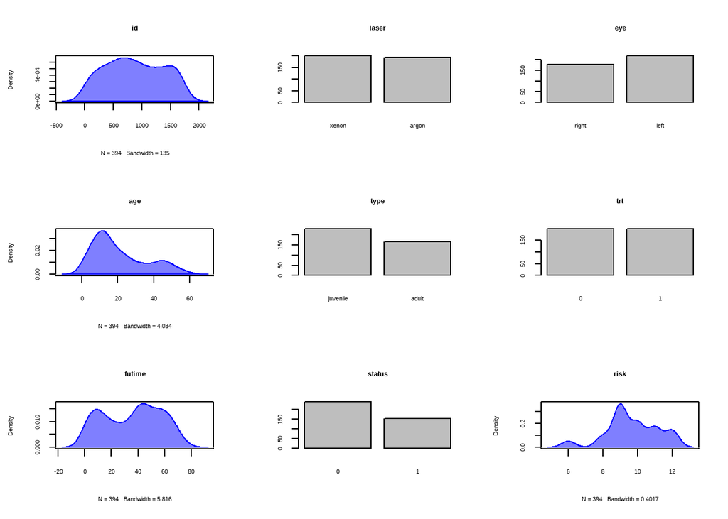

```r
retinopathy$trt <- as.factor(retinopathy$trt)
retinopathy$status <- as.factor(retinopathy$status)

plot_summary <- function(dt, dim_row, dim_col){
  par(mfrow = c(dim_row, dim_col))
  for (j in 1:dim(dt)[2]){
    if (is.numeric(dt[,j])){
      plot(density(dt[,j]), col = rgb(0,0,1,0.5), main = paste0(colnames(dt)[j]))
      polygon(density(dt[,j]), col = rgb(0,0,1,0.5), border = "blue")
    } else if (is.factor(dt[,j])){
      plot(dt[,j], main = paste0(colnames(dt)[j]))
    }
  }
}
plot_summary(retinopathy, 3, 3)
```

### Subsetting

#### Task 1

For each data set (**heart** and **retinopathy**), select only the observations that report an event.

Note that the variable name of the events is diffent for the two data sets.

#### Solution 1

```r
heart[heart$event == 1, ]
```

|  | start | stop | event | age | year | surgery | transplant | id |
| --- | --- | --- | --- | --- | --- | --- | --- | --- |
| 1 | 0.0 | 50 | 1 | -17.15537303 | 0.12320329 | 0 | 0 | 1 |
| 2 | 0.0 | 6 | 1 | 3.83572895 | 0.25462012 | 0 | 0 | 2 |
| 4 | 1.0 | 16 | 1 | 6.29705681 | 0.26557153 | 0 | 1 | 3 |
| 6 | 36.0 | 39 | 1 | -7.73716632 | 0.49007529 | 0 | 1 | 4 |
| 7 | 0.0 | 18 | 1 | -27.21423682 | 0.60780287 | 0 | 0 | 5 |
| 8 | 0.0 | 3 | 1 | 6.59548255 | 0.70088980 | 0 | 0 | 6 |
| 10 | 51.0 | 675 | 1 | 2.86926762 | 0.78028747 | 0 | 1 | 7 |
| 11 | 0.0 | 40 | 1 | -2.65023956 | 0.83504449 | 0 | 0 | 8 |
| 12 | 0.0 | 85 | 1 | -0.83778234 | 0.85694730 | 0 | 0 | 9 |
| 14 | 12.0 | 58 | 1 | -5.49760438 | 0.86242300 | 0 | 1 | 10 |

[output cut: 65 more lines]

```r
retinopathy[retinopathy$status == 1, ]
```

|  | id | laser | eye | age | type | trt | futime | status | risk |
| --- | --- | --- | --- | --- | --- | --- | --- | --- | --- |
| 4 | 14 | argon | right | 12 | juvenile | 0 | 31.30 | 1 | 6 |
| 10 | 29 | xenon | left | 13 | juvenile | 0 | 0.30 | 1 | 10 |
| 12 | 46 | xenon | right | 12 | juvenile | 0 | 54.27 | 1 | 9 |
| 14 | 49 | argon | right | 8 | juvenile | 0 | 10.80 | 1 | 6 |
| 20 | 71 | argon | right | 21 | adult | 0 | 13.83 | 1 | 9 |
| 21 | 100 | argon | left | 23 | adult | 1 | 46.43 | 1 | 9 |
| 24 | 112 | argon | right | 44 | adult | 0 | 7.90 | 1 | 12 |
| 27 | 127 | xenon | right | 48 | adult | 1 | 30.83 | 1 | 6 |
| 28 | 127 | xenon | right | 48 | adult | 0 | 38.57 | 1 | 10 |
| 30 | 133 | argon | right | 26 | adult | 0 | 14.10 | 1 | 9 |

[output cut: 145 more lines]

#### Task 2

Create a function with the name `dt_events` that takes as input a list with data sets (let’s call it `dt_list`) and a vector indicating the name of the event variable for each data set (let’s call it `event_name`). The function will return a list consisting of each data set but including only the observations/rows that had an event. Create a list that consists of the data sets **heart** and **retinopathy** and apply the function.

Use a for loop. Note that the variable name of the events is different for the two data sets.

#### Solution 2

```r
dt_events <- function(dt_lists, event_name){
  new_dt <- list()
  for (k in 1:length(dt_lists)) {
      dt <- dt_lists[[k]]
      new_dt[[k]] <- dt[dt[[event_name[k]]] == 1, ]
  }
  print(new_dt)
}

dt_events(dt_lists = list(heart, retinopathy), event_name = c("event", "status"))
```

```
## [[1]]
##     start stop event          age        year surgery transplant  id
## 1     0.0   50     1 -17.15537303  0.12320329       0          0   1
## 2     0.0    6     1   3.83572895  0.25462012       0          0   2
## 4     1.0   16     1   6.29705681  0.26557153       0          1   3
## 6    36.0   39     1  -7.73716632  0.49007529       0          1   4
## 7     0.0   18     1 -27.21423682  0.60780287       0          0   5
## 8     0.0    3     1   6.59548255  0.70088980       0          0   6
## 10   51.0  675     1   2.86926762  0.78028747       0          1   7
## 11    0.0   40     1  -2.65023956  0.83504449       0          0   8
## 12    0.0   85     1  -0.83778234  0.85694730       0          0   9
## 14   12.0   58     1  -5.49760438  0.86242300       0          1  10
## 16   26.0  153     1  -0.01916496  0.87337440       0          1  11
## 17    0.0    8     1   5.19370294  0.96372348       0          0  12
## 19   17.0   81     1   6.57357974  0.96919918       0          1  13
```

[output cut: 177 more lines]

### The Apply family

#### Task 1

For each data set (**heart** and **retinopathy**), obtain the mean age per event status.

#### Solution 1

```r
tapply(heart$age, heart$event, mean)
```

```
##         0         1
## -3.421947 -1.270983
```

```r
tapply(retinopathy$age, retinopathy$status, mean)
```

```
##        0        1
## 20.35146 21.44516
```

#### Task 2

Create a function with the name `summary_list` that takes as input a list with data sets (let’s call it `dt_list`), a vector with the names of the continuous variables (let’s call it `dt_cont`) and a vector with the names of the categorical variables (let’s call it `dt_cat`) and returns the mean of the continuous variable per group (categorical variable) for each data set. Apply the function to the **heart** and **retinopathy** data sets. In particular, use the continuous variables `year` (from the **heart** data set) and `risk` (from the **retinopathy** data set) and the categorical variables `surgery` (from the **heart** data set) and `type` (from the **retinopathy** data set).

Use a for loop. Use the print(…) function to print the results.

#### Solution 2

```r
summary_list <- function(dt_list, dt_cont, dt_cat){
  for (i in 1:length(dt_list)){
    dt <- dt_list[[i]]
    print(tapply(dt[[dt_cont[i]]], dt[[dt_cat[i]]], mean))
  }
}

summary_list(dt_list = list(heart, retinopathy), dt_cont = c("year", "risk"), dt_cat = c("surgery", "type"))
```

```
##        0        1
## 3.320975 4.105738
## juvenile    adult
## 9.745614 9.632530
```

#### Task 3

Extend the previous by including an extra input argument (let’s call it `calc`) which will indicate each time the measure that we want to calculate e.g, the mean. So that the user can decide which function to use.

#### Solution 3

```r
summary_list <- function(dt_list, dt_cont, dt_cat, calc){
  for (i in 1:length(dt_list)){
    dt <- dt_list[[i]]
    print(tapply(dt[[dt_cont[i]]], dt[[dt_cat[i]]], calc))
  }
}

summary_list(dt_list = list(heart, retinopathy), dt_cont = c("year", "risk"), dt_cat = c("surgery", "type"), calc = median)
```

```
##        0        1
## 3.564682 3.978097
## juvenile    adult
##       10        9
```

© Eleni-Rosalina Andrinopoulou